# EDA — `03_monitoring` (RISA_DATA_V1.0)

**HealthSignal LATAM · Hackathon Perú 2026**

Esta es la capa de monitoreo: `device_observations` (calidad de señal de monitores clínicos/ domiciliarios), `vital_signs` (signos vitales de dispositivos clínicos) y `wearable_observations` (frecuencia cardiaca, pasos y nivel de actividad del wearable de muñeca). Son, por lejos, **los archivos más pesados del paquete** (`vital_signs.csv` ~160 MB / 1.62M filas, `wearable_observations.csv` ~90 MB / 895K filas), y también donde se concentra la señal multivariable/temporal que el reto pide analizar.

**Nota de performance:** se cargan las 3 tablas una sola vez en la celda de setup, usando dtype `category` para las columnas repetitivas (`patient_id`, `device_id`, `variable_code`, `unit`, `quality_flag`). Esto reduce el uso de memoria en más de 60% frente a cargar todo como texto plano y hace que el resto del notebook opere sobre los DataFrames ya en memoria (sin releer CSV en cada celda).

```python
import pandas as pd
import numpy as np
import matplotlib.pyplot as plt
import seaborn as sns
import time

pd.set_option('display.max_columns', 50)
pd.set_option('display.width', 160)
sns.set_theme(style='whitegrid', palette='Set2')
plt.rcParams['figure.dpi'] = 110

MASTER_DIR = "../data/raw/01_master"
META_DIR   = "../data/raw/05_metadata"
DATA_DIR   = "../data/raw/03_monitoring"

devices  = pd.read_csv(f"{MASTER_DIR}/devices.csv")
varcat   = pd.read_csv(f"{META_DIR}/variable_catalog.csv").set_index('variable_code')
unitscat = pd.read_csv(f"{META_DIR}/units_catalog.csv").set_index('unit_code')

t0 = time.time()
device_obs = pd.read_csv(f"{DATA_DIR}/device_observations.csv",
                          dtype={'patient_id':'category','device_id':'category',
                                 'variable_code':'category','unit':'category',
                                 'source_system':'category'})
vital_signs = pd.read_csv(f"{DATA_DIR}/vital_signs.csv",
                           dtype={'patient_id':'category','device_id':'category',
                                  'variable_code':'category','unit':'category',
                                  'source_system':'category','quality_flag':'category'})
wearable_obs = pd.read_csv(f"{DATA_DIR}/wearable_observations.csv",
                            dtype={'patient_id':'category','device_id':'category',
                                   'variable_code':'category','unit':'category',
                                   'measurement_quality':'category'})
print(f"Carga completa en {time.time()-t0:.1f} s")

for name, df in [("device_observations", device_obs), ("vital_signs", vital_signs),
                  ("wearable_observations", wearable_obs)]:
    mb = df.memory_usage(deep=True).sum() / 1e6
    print(f"{name:22s} -> {df.shape[0]:>9,d} filas x {df.shape[1]} cols  |  {mb:>7.1f} MB en memoria")
```

```
Carga completa en 6.6 s
device_observations    ->    13,329 filas x 10 cols  |      3.3 MB en memoria
```

```
vital_signs            -> 1,622,969 filas x 10 cols  |    373.5 MB en memoria
```

```
wearable_observations  ->   895,551 filas x 9 cols  |    261.5 MB en memoria
```

## 1. `device_observations` — calidad de señal de monitores

13,329 registros. Es una tabla de una sola variable: `SIGNAL_QUALITY_INDEX` (0–1), reportada periódicamente por cada monitor clínico/domiciliario (`DEV-xxxxx`).

```python
print(device_obs.dtypes)
device_obs.head()
```

```
device_observation_id         str
patient_id               category
encounter_id                  str
device_id                category
timestamp                     str
variable_code            category
value                     float64
unit                     category
signal_quality            float64
source_system            category
dtype: object
```

|  | device_observation_id | patient_id | encounter_id | device_id | timestamp | variable_code | value | unit | signal_quality | source_system |
| --- | --- | --- | --- | --- | --- | --- | --- | --- | --- | --- |
| 0 | DOBS-000000001 | PAT-0001 | ENC-000001 | DEV-00001 | 2026-07-10 09:00:00 | SIGNAL_QUALITY_INDEX | 0.930 | ratio | 0.930 | MONITOR_GATEWAY |
| 1 | DOBS-000000002 | PAT-0001 | ENC-000001 | DEV-00001 | 2026-07-10 21:00:00 | SIGNAL_QUALITY_INDEX | 0.931 | ratio | 0.931 | MONITOR_GATEWAY |
| 2 | DOBS-000000003 | PAT-0001 | ENC-000001 | DEV-00001 | 2026-07-11 09:00:00 | SIGNAL_QUALITY_INDEX | 0.930 | ratio | 0.930 | MONITOR_GATEWAY |
| 3 | DOBS-000000004 | PAT-0001 | ENC-000001 | DEV-00001 | 2026-07-11 21:00:00 | SIGNAL_QUALITY_INDEX | 0.859 | ratio | 0.859 | MONITOR_GATEWAY |
| 4 | DOBS-000000005 | PAT-0001 | ENC-000001 | DEV-00001 | 2026-07-12 09:00:00 | SIGNAL_QUALITY_INDEX | 1.000 | ratio | 1.000 | MONITOR_GATEWAY |

```python
print("Nulos por columna:")
print(device_obs.isnull().sum())
print("\nDuplicados exactos:", device_obs.duplicated().sum())
print("\nvariable_code:", device_obs['variable_code'].unique().tolist())
print("source_system:", device_obs['source_system'].unique().tolist())
print("\nsignal_quality — describe:")
print(device_obs['signal_quality'].describe())
```

```
Nulos por columna:
device_observation_id    0
patient_id               0
encounter_id             0
device_id                0
timestamp                0
variable_code            0
value                    0
unit                     0
signal_quality           0
source_system            0
dtype: int64

Duplicados exactos: 0

variable_code: ['SIGNAL_QUALITY_INDEX']
source_system: ['MONITOR_GATEWAY']

signal_quality — describe:
count    13329.000000
mean         0.924487
std          0.061739
min          0.420000
25%          0.890000
50%          0.930000
75%          0.970000
max          1.000000
Name: signal_quality, dtype: float64
```

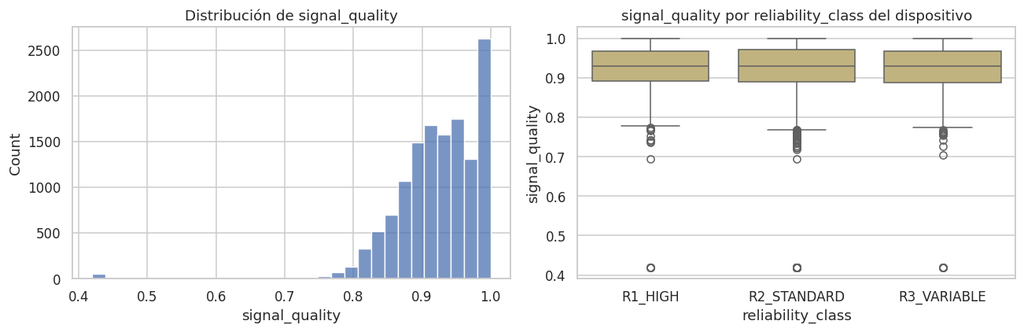

```
signal_quality promedio por reliability_class:
                       mean       std  count
reliability_class
R1_HIGH            0.924930  0.059884   2554
R2_STANDARD        0.924855  0.062283   8414
R3_VARIABLE        0.922700  0.061760   2361
```

```python
fig, axes = plt.subplots(1, 2, figsize=(12, 4))

sns.histplot(device_obs['signal_quality'], bins=30, ax=axes[0], color='#4C72B0')
axes[0].set_title('Distribución de signal_quality')

device_rel = device_obs.merge(devices[['device_id','reliability_class']], on='device_id', how='left')
sns.boxplot(data=device_rel, x='reliability_class', y='signal_quality',
            order=['R1_HIGH','R2_STANDARD','R3_VARIABLE'], ax=axes[1], color='#CCB974')
axes[1].set_title('signal_quality por reliability_class del dispositivo')

plt.tight_layout()
plt.show()

print("signal_quality promedio por reliability_class:")
print(device_rel.groupby('reliability_class', observed=True)['signal_quality'].agg(['mean','std','count']))
```

**Comentario:** la mediana de `signal_quality` es alta (~0.93) pero con una cola hacia abajo (mínimo 0.42). Sorprende que **la clase de confiabilidad del dispositivo (`reliability_class`, metadato estático de `01_master/devices.csv`) casi no explica la variación real de `signal_quality`** — las medias por clase son prácticamente iguales. Conclusión práctica: no conviene usar `reliability_class` como proxy de confianza de la señal; hay que mirar el `signal_quality` (o `quality_flag`) observación por observación.

## 2. `vital_signs` — la tabla más grande y con más señal de riesgo

1,622,969 registros. Signos vitales de dispositivos clínicos: `HR`, `RR`, `SpO2`, `TEMP`, `SBP`, `DBP`. Aquí es donde aparecen los problemas de calidad "de verdad" del dataset.

```python
print(vital_signs.dtypes)
vital_signs.head()
```

```
observation_id         str
patient_id        category
encounter_id           str
timestamp              str
variable_code     category
value              float64
unit              category
device_id         category
source_system     category
quality_flag      category
dtype: object
```

|  | observation_id | patient_id | encounter_id | timestamp | variable_code | value | unit | device_id | source_system | quality_flag |
| --- | --- | --- | --- | --- | --- | --- | --- | --- | --- | --- |
| 0 | OBS-0000000001 | PAT-0001 | ENC-000001 | 2026-07-10 09:00:00 | HR | 74.346 | bpm | DEV-00001 | MONITOR_GATEWAY | OK |
| 1 | OBS-0000000002 | PAT-0001 | ENC-000001 | 2026-07-10 09:20:00 | HR | 71.325 | bpm | DEV-00001 | MONITOR_GATEWAY | OK |
| 2 | OBS-0000000003 | PAT-0001 | ENC-000001 | 2026-07-10 09:40:00 | HR | 70.479 | bpm | DEV-00001 | MONITOR_GATEWAY | OK |
| 3 | OBS-0000000004 | PAT-0001 | ENC-000001 | 2026-07-10 10:00:00 | HR | 73.271 | bpm | DEV-00001 | MONITOR_GATEWAY | OK |
| 4 | OBS-0000000005 | PAT-0001 | ENC-000001 | 2026-07-10 10:20:00 | HR | 77.848 | bpm | DEV-00001 | MONITOR_GATEWAY | OK |

```python
print("Nulos por columna:")
print(vital_signs.isnull().sum())
print("\nDuplicados exactos (fila completa):", vital_signs.duplicated().sum())
print("observation_id duplicados:", vital_signs['observation_id'].duplicated().sum())

dup_key = vital_signs.duplicated(subset=['patient_id','variable_code','timestamp']).sum()
print("\nDuplicados por (patient_id, variable_code, timestamp):", dup_key)

print("\n--- Integridad referencial ---")
print("patient_id no está en devices/patients maestro:",
      (~vital_signs['patient_id'].astype(str).isin(devices['assigned_patient_id'].astype(str))).sum())
```

```
Nulos por columna:
```

```
observation_id    0
patient_id        0
encounter_id      0
timestamp         0
variable_code     0
value             0
unit              0
device_id         0
source_system     0
quality_flag      0
dtype: int64
```

```
Duplicados exactos (fila completa): 0
```

```
observation_id duplicados: 0
```

```
Duplicados por (patient_id, variable_code, timestamp): 540

--- Integridad referencial ---
patient_id no está en devices/patients maestro: 0
```

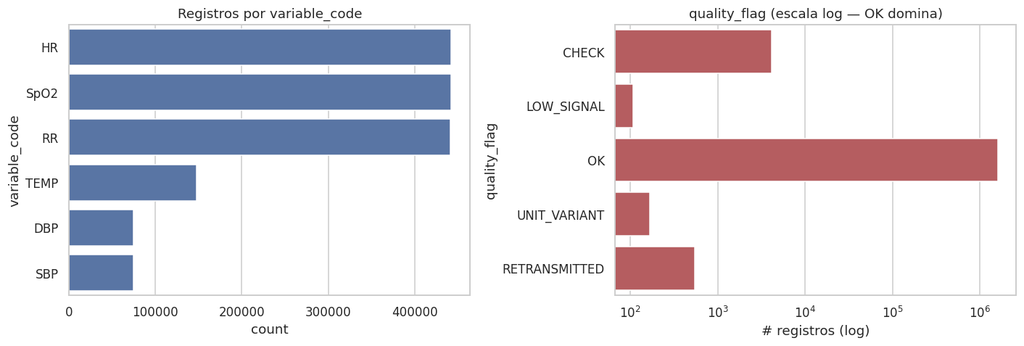

```
quality_flag
OK               1617991
CHECK               4164
RETRANSMITTED        540
UNIT_VARIANT         166
LOW_SIGNAL           108
Name: count, dtype: int64
```

```python
fig, axes = plt.subplots(1, 2, figsize=(13, 4.5))

sns.countplot(data=vital_signs, y='variable_code',
              order=vital_signs['variable_code'].value_counts().index, ax=axes[0], color='#4C72B0')
axes[0].set_title('Registros por variable_code')

qf = vital_signs['quality_flag'].value_counts()
sns.barplot(x=qf.values, y=qf.index, ax=axes[1], color='#C44E52')
axes[1].set_xscale('log')
axes[1].set_title('quality_flag (escala log — OK domina)')
axes[1].set_xlabel('# registros (log)')

plt.tight_layout()
plt.show()
print(qf)
```

### 2.1 Hallazgo: mezcla de unidades en `TEMP` (`UNIT_VARIANT`)

166 registros de temperatura vienen en grados Fahrenheit (`degF`) mientras el resto está en Celsius (`degC`). Si no se convierten antes de analizar, esos 166 valores (≈97–99, que son temperaturas corporales normales *en Fahrenheit*) aparecen como fisiológicamente imposibles.

```python
temp = vital_signs[vital_signs['variable_code']=='TEMP'].merge(
    unitscat[['conversion_factor','conversion_offset']], left_on='unit', right_index=True)
temp['value_canonical'] = temp['value']*temp['conversion_factor'] + temp['conversion_offset']

print("Valor crudo por unidad:")
print(temp.groupby('unit', observed=True)['value'].agg(['count','mean','min','max']))
print("\nValor convertido a unidad canónica (degC):")
print(temp.groupby('unit', observed=True)['value_canonical'].agg(['count','mean','min','max']))

lo, hi = varcat.loc['TEMP', ['plausibility_min','plausibility_max']]
print(f"\nRango plausible TEMP: [{lo}, {hi}] degC")
print("Fuera de rango ANTES de convertir unidad:", ((temp['value']<lo)|(temp['value']>hi)).sum())
print("Fuera de rango DESPUÉS de convertir unidad:", ((temp['value_canonical']<lo)|(temp['value_canonical']>hi)).sum())
```

```
Valor crudo por unidad:
       count       mean     min     max
unit
degC  147783  36.715898  35.369  38.692
degF     166  98.147241  97.252  99.447

Valor convertido a unidad canónica (degC):
       count       mean        min        max
unit
degC  147783  36.715898  35.369000  38.692000
degF     166  36.748467  36.251111  37.470556

Rango plausible TEMP: [30.0, 45.0] degC
Fuera de rango ANTES de convertir unidad: 166
Fuera de rango DESPUÉS de convertir unidad: 0
```

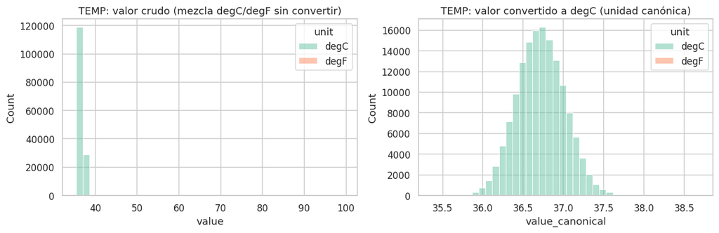

```python
fig, axes = plt.subplots(1, 2, figsize=(12, 4))
sns.histplot(data=temp, x='value', hue='unit', bins=40, ax=axes[0])
axes[0].set_title('TEMP: valor crudo (mezcla degC/degF sin convertir)')
sns.histplot(data=temp, x='value_canonical', hue='unit', bins=40, ax=axes[1])
axes[1].set_title('TEMP: valor convertido a degC (unidad canónica)')
plt.tight_layout()
plt.show()
```

**Implicación para el pipeline:** cualquier verificación de plausibilidad o umbral clínico tiene que aplicarse **después** de normalizar unidades usando `units_catalog.csv` (`unit` de cada fila + `conversion_factor`/`conversion_offset`), nunca contra el valor crudo. Ya lo señala `quality_flag = UNIT_VARIANT`, pero conviene no depender solo de esa bandera: conviene normalizar unidades de forma sistemática para *todas* las variables, no solo cuando el dataset ya avisó.

### 2.2 Hallazgo: valores fisiológicamente imposibles marcados como `OK`

`SpO2` (saturación de oxígeno) tiene un límite físico de 100%. El catálogo de variables define un rango plausible de 50–100%.

```
SpO2 fuera de rango plausible: 734 / 441998 (0.166%)
quality_flag
OK               549
CHECK            185
LOW_SIGNAL         0
UNIT_VARIANT       0
RETRANSMITTED      0
Name: count, dtype: int64

Describe de los valores fuera de rango:
count    734.000000
mean     100.612319
std        0.888027
min      100.001000
25%      100.106000
50%      100.274500
75%      100.619250
max      106.612000
Name: value, dtype: float64
```

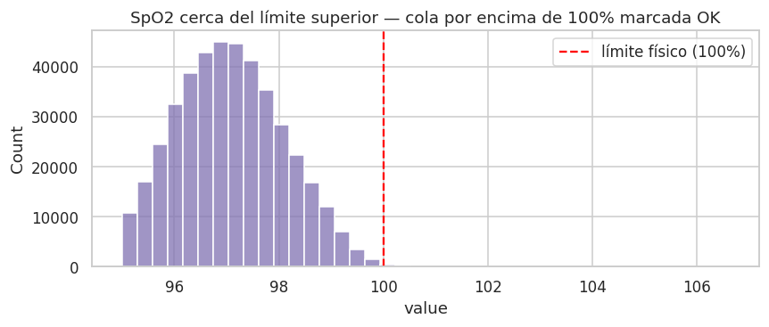

```python
spo2 = vital_signs[vital_signs['variable_code']=='SpO2'].merge(
    varcat[['plausibility_min','plausibility_max']], left_on='variable_code', right_index=True)
out = (spo2['value']<spo2['plausibility_min']) | (spo2['value']>spo2['plausibility_max'])
print(f"SpO2 fuera de rango plausible: {out.sum()} / {len(spo2)} ({out.mean()*100:.3f}%)")
print(spo2.loc[out, 'quality_flag'].value_counts())
print("\nDescribe de los valores fuera de rango:")
print(spo2.loc[out, 'value'].describe())

plt.figure(figsize=(8, 3.5))
sns.histplot(spo2.loc[spo2['value']>95, 'value'], bins=40, color='#8172B2')
plt.axvline(100, color='red', ls='--', label='límite físico (100%)')
plt.title('SpO2 cerca del límite superior — cola por encima de 100% marcada OK')
plt.legend()
plt.tight_layout()
plt.show()
```

**Comentario clave:** 549 de los 734 valores de SpO2 fuera de rango (≈75%) están marcados como `quality_flag = OK` — es decir, **la bandera de calidad del dataset no captura este tipo de ruido de sensor**. Son desviaciones pequeñas (100.0–106.6%), típicas de ruido de medición cerca del techo de la escala. El motor de validación de HealthSignal no puede confiar únicamente en `quality_flag`; necesita sus propias reglas de plausibilidad por variable (ya provistas en `variable_catalog.csv`) como una capa adicional, independiente de lo que reporte la fuente.

### 2.3 Hallazgo: registros retransmitidos generan duplicados en el tiempo

```python
dup_key = vital_signs.duplicated(subset=['patient_id','variable_code','timestamp'], keep=False)
print("Filas involucradas en duplicados (patient_id, variable_code, timestamp):", dup_key.sum())
print("\nquality_flag de esas filas:")
print(vital_signs.loc[dup_key, 'quality_flag'].value_counts())
print("\nsource_system de esas filas:")
print(vital_signs.loc[dup_key, 'source_system'].value_counts())

ejemplo_id = vital_signs.loc[dup_key, 'patient_id'].iloc[0]
ejemplo_var = vital_signs.loc[dup_key, 'variable_code'].iloc[0]
cols = ['patient_id','variable_code','timestamp','value','quality_flag','source_system']
print(f"\nEjemplo — {ejemplo_id} / {ejemplo_var}:")
print(vital_signs[(vital_signs['patient_id']==ejemplo_id) & (vital_signs['variable_code']==ejemplo_var)]
      .sort_values('timestamp')[cols].head(6))
```

```
Filas involucradas en duplicados (patient_id, variable_code, timestamp): 1080

quality_flag de esas filas:
quality_flag
RETRANSMITTED    540
OK               539
CHECK              1
LOW_SIGNAL         0
UNIT_VARIANT       0
Name: count, dtype: int64

source_system de esas filas:
source_system
MONITOR_GATEWAY       540
MONITOR_RETRANSMIT    540
Name: count, dtype: int64

Ejemplo — PAT-0021 / HR:
      patient_id variable_code            timestamp   value quality_flag    source_system
47087   PAT-0021            HR  2026-07-19 12:15:00  64.104           OK  MONITOR_GATEWAY
47088   PAT-0021            HR  2026-07-19 12:35:00  64.082           OK  MONITOR_GATEWAY
47089   PAT-0021            HR  2026-07-19 12:55:00  60.361           OK  MONITOR_GATEWAY
47090   PAT-0021            HR  2026-07-19 13:15:00  68.346           OK  MONITOR_GATEWAY
47091   PAT-0021            HR  2026-07-19 13:35:00  64.798           OK  MONITOR_GATEWAY
47092   PAT-0021            HR  2026-07-19 13:55:00  66.192           OK  MONITOR_GATEWAY
```

**Comentario:** los 540 registros con `quality_flag = RETRANSMITTED` (todos vía `source_system = MONITOR_RETRANSMIT`) generan exactamente 540 pares con `timestamp` duplicado para el mismo paciente y variable — el gateway reenvía una lectura que ya había llegado. El pipeline de integración necesita una regla de deduplicación explícita (p. ej. quedarse con la versión no retransmitida, o la más reciente por `source_system`) antes de construir series de tiempo, o el mismo evento se contará dos veces.

### 2.4 Frecuencia de muestreo real vs. nominal (por variable)

El catálogo de variables define una frecuencia de muestreo nominal por variable (`nominal_sampling`). Comparamos contra el gap real entre observaciones consecutivas del mismo paciente/variable.

```
                     mean  median    min    max nominal_sampling
variable_code
DBP            121.454664   120.0  120.0  360.0       30-360 min
HR              20.223785    20.0    0.0   80.0         5-15 min
RR              20.244517    20.0    0.0   80.0        10-30 min
SBP            121.446531   120.0  120.0  480.0       30-360 min
SpO2            20.238641    20.0   20.0  100.0         5-15 min
TEMP            60.717392    60.0   60.0  180.0       30-240 min
```

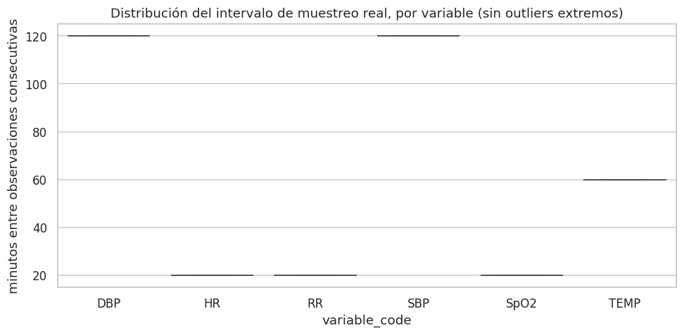

```python
vital_signs['timestamp'] = pd.to_datetime(vital_signs['timestamp'])
vs_sorted = vital_signs.sort_values(['patient_id','variable_code','timestamp'])
gaps_min = vs_sorted.groupby(['patient_id','variable_code'], observed=True)['timestamp'].diff().dt.total_seconds() / 60

gap_stats = gaps_min.groupby(vs_sorted['variable_code'], observed=True).agg(['mean','median','min','max'])
gap_stats = gap_stats.join(varcat['nominal_sampling'])
print(gap_stats)

plt.figure(figsize=(9, 4.5))
sns.boxplot(x=vs_sorted['variable_code'], y=gaps_min, order=gap_stats.index, showfliers=False, color='#55A868')
plt.ylabel('minutos entre observaciones consecutivas')
plt.title('Distribución del intervalo de muestreo real, por variable (sin outliers extremos)')
plt.tight_layout()
plt.show()
```

### 2.5 Serie de tiempo de ejemplo

Para hacer tangible lo anterior, se grafica `HR` de un paciente real a lo largo de su episodio, marcando los puntos con `quality_flag` distinto de `OK`.

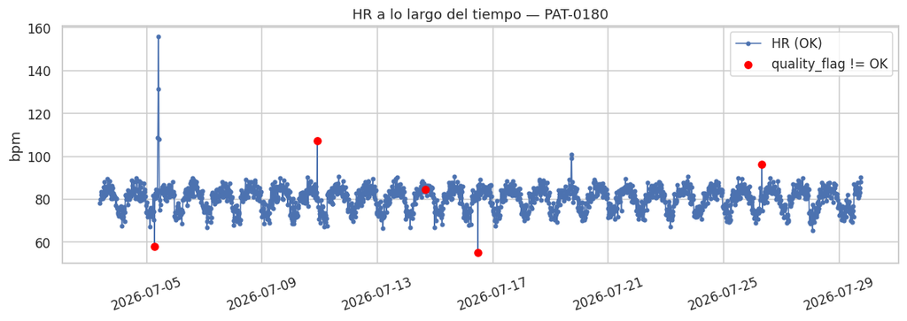

```python
ejemplo_pid = vital_signs['patient_id'].value_counts().index[0]
hr_ej = vital_signs[(vital_signs['patient_id']==ejemplo_pid) & (vital_signs['variable_code']=='HR')].sort_values('timestamp')

plt.figure(figsize=(11, 4))
plt.plot(hr_ej['timestamp'], hr_ej['value'], '-o', ms=3, lw=1, color='#4C72B0', label='HR (OK)')
flagged = hr_ej[hr_ej['quality_flag']!='OK']
if len(flagged):
    plt.scatter(flagged['timestamp'], flagged['value'], color='red', zorder=5, label='quality_flag != OK')
plt.title(f'HR a lo largo del tiempo — {ejemplo_pid}')
plt.ylabel('bpm')
plt.legend()
plt.xticks(rotation=20)
plt.tight_layout()
plt.show()
```

## 3. `wearable_observations` — wearable de muñeca

895,551 registros: `WEARABLE_HR`, `STEPS` y `ACTIVITY_LEVEL`, cada una con ~298,517 filas (muestreo sincronizado entre las 3 variables).

```python
print(wearable_obs.dtypes)
wearable_obs.head()
```

```
wearable_observation_id         str
patient_id                 category
device_id                  category
timestamp                       str
variable_code              category
value                           str
unit                       category
measurement_quality        category
sync_datetime                   str
dtype: object
```

|  | wearable_observation_id | patient_id | device_id | timestamp | variable_code | value | unit | measurement_quality | sync_datetime |
| --- | --- | --- | --- | --- | --- | --- | --- | --- | --- |
| 0 | WOBS-0000000001 | PAT-0001 | WRB-00001 | 2026-07-10 09:00:00 | WEARABLE_HR | 70.194 | bpm | OK | 2026-07-10 09:04:00 |
| 1 | WOBS-0000000002 | PAT-0001 | WRB-00001 | 2026-07-10 09:00:00 | STEPS | 0 | count | OK | 2026-07-10 09:04:00 |
| 2 | WOBS-0000000003 | PAT-0001 | WRB-00001 | 2026-07-10 09:00:00 | ACTIVITY_LEVEL | REST | category | OK | 2026-07-10 09:04:00 |
| 3 | WOBS-0000000004 | PAT-0001 | WRB-00001 | 2026-07-10 09:30:00 | WEARABLE_HR | 73.361 | bpm | OK | 2026-07-10 09:33:00 |
| 4 | WOBS-0000000005 | PAT-0001 | WRB-00001 | 2026-07-10 09:30:00 | STEPS | 0 | count | OK | 2026-07-10 09:33:00 |

```python
print("Nulos por columna:")
print(wearable_obs.isnull().sum())
print("\nDuplicados exactos:", wearable_obs.duplicated().sum())
dup_key = wearable_obs.duplicated(subset=['patient_id','variable_code','timestamp']).sum()
print("Duplicados por (patient_id, variable_code, timestamp):", dup_key)
print("\nmeasurement_quality:")
print(wearable_obs['measurement_quality'].value_counts())
```

```
Nulos por columna:
wearable_observation_id    0
patient_id                 0
device_id                  0
timestamp                  0
variable_code              0
value                      0
unit                       0
measurement_quality        0
sync_datetime              0
dtype: int64
```

```
Duplicados exactos: 0
Duplicados por (patient_id, variable_code, timestamp): 0

measurement_quality:
measurement_quality
OK    895551
Name: count, dtype: int64
```

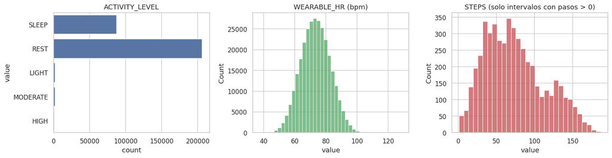

```
WEARABLE_HR fuera de rango plausible [20.0,220.0]: 0 / 298517
```

```python
fig, axes = plt.subplots(1, 3, figsize=(15, 4))

al = wearable_obs[wearable_obs['variable_code']=='ACTIVITY_LEVEL']
order_al = ['SLEEP','REST','LIGHT','MODERATE','HIGH']
sns.countplot(y=al['value'], order=[o for o in order_al if o in al['value'].unique()], ax=axes[0], color='#4C72B0')
axes[0].set_title('ACTIVITY_LEVEL')

hr_w = pd.to_numeric(wearable_obs.loc[wearable_obs['variable_code']=='WEARABLE_HR', 'value'])
sns.histplot(hr_w, bins=40, ax=axes[1], color='#55A868')
axes[1].set_title('WEARABLE_HR (bpm)')

steps = pd.to_numeric(wearable_obs.loc[wearable_obs['variable_code']=='STEPS', 'value'])
sns.histplot(steps[steps>0], bins=30, ax=axes[2], color='#C44E52')
axes[2].set_title('STEPS (solo intervalos con pasos > 0)')

plt.tight_layout()
plt.show()

lo, hi = varcat.loc['WEARABLE_HR', ['plausibility_min','plausibility_max']]
out_hr = ((hr_w<lo)|(hr_w>hi)).sum()
print(f"WEARABLE_HR fuera de rango plausible [{lo},{hi}]: {out_hr} / {len(hr_w)}")
```

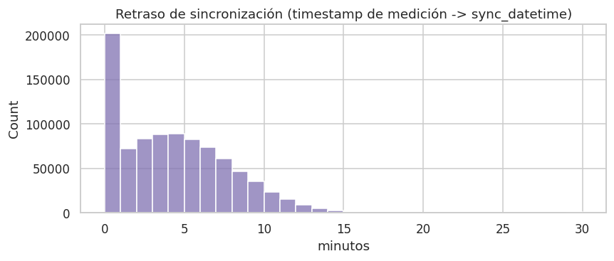

```
count    895551.000000
mean          3.958816
std           3.513645
min           0.000000
25%           1.000000
50%           4.000000
75%           6.000000
max          30.000000
dtype: float64
Registros con sync ANTES de la medición (anomalía): 0
```

```python
wearable_obs['timestamp'] = pd.to_datetime(wearable_obs['timestamp'])
wearable_obs['sync_datetime'] = pd.to_datetime(wearable_obs['sync_datetime'])
sync_delay_min = (wearable_obs['sync_datetime'] - wearable_obs['timestamp']).dt.total_seconds() / 60

plt.figure(figsize=(8, 3.5))
sns.histplot(sync_delay_min, bins=30, color='#8172B2')
plt.title('Retraso de sincronización (timestamp de medición -> sync_datetime)')
plt.xlabel('minutos')
plt.tight_layout()
plt.show()
print(sync_delay_min.describe())
print("Registros con sync ANTES de la medición (anomalía):", (sync_delay_min<0).sum())
```

**Comentario:** el wearable mide en tiempo real pero **sincroniza con retraso** (0 a 30 min, mediana 4 min) — a diferencia de `vital_signs`, donde `timestamp` ya es prácticamente el momento de disponibilidad. Esto importa para alertas casi en tiempo real: una lectura de wearable "ya ocurrió" hasta 30 minutos antes de que el sistema la vea, y ese retraso debe considerarse como parte de la latencia total de la señal, no solo el gap de muestreo.

### 3.1 Cruce: HR clínico (`vital_signs`) vs. HR del wearable, mismo paciente

Dos fuentes miden lo mismo (frecuencia cardiaca) con distinta cadencia y distinto dispositivo — el caso de libro de texto de integración multivariable/multi-fuente que pide el reto.

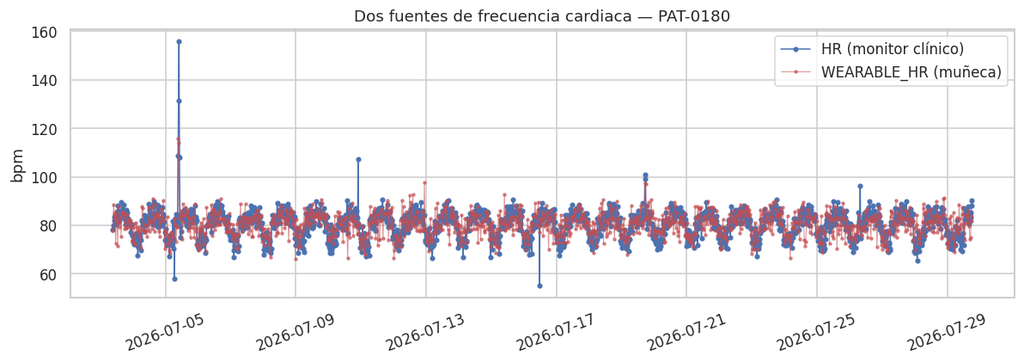

```python
pid = ejemplo_pid  # mismo paciente de la sección 2.5
hr_clin = vital_signs[(vital_signs['patient_id']==pid) & (vital_signs['variable_code']=='HR')].sort_values('timestamp')
hr_wear = wearable_obs[(wearable_obs['patient_id']==pid) & (wearable_obs['variable_code']=='WEARABLE_HR')].sort_values('timestamp')
hr_wear_val = pd.to_numeric(hr_wear['value'])

plt.figure(figsize=(11, 4))
plt.plot(hr_clin['timestamp'], hr_clin['value'], '-o', ms=3, lw=1, color='#4C72B0', label='HR (monitor clínico)')
plt.plot(hr_wear['timestamp'], hr_wear_val, '-o', ms=2, lw=0.7, alpha=0.6, color='#C44E52', label='WEARABLE_HR (muñeca)')
plt.title(f'Dos fuentes de frecuencia cardiaca — {pid}')
plt.ylabel('bpm')
plt.legend()
plt.xticks(rotation=20)
plt.tight_layout()
plt.show()
```

**Siguiente paso sugerido:** con `01_master`, `02_clinical` y `03_monitoring` ya caracterizados, el pipeline de integración puede definirse con reglas concretas: normalizar unidades, deduplicar retransmisiones, validar plausibilidad por variable de forma independiente al `quality_flag`, y resamplear/alinear por paciente respetando la cobertura real de cada ventana antes de calcular cualquier feature multivariable para el motor de señales de riesgo.